# Ch 11 exercises

#### Can you think of ways to simplify the analysis of this data set?

**Simpler is better when explaining your analysis to an audience!**

> One simple step is to recognize that the individual growth measurements aren’t independent experimental units, but from animals within the same Predation treatment unit. We could replace the individual observations with the mean of animals within each plot. We’d get a slightly simpler analysis, but not markedly so.

> The bigger step would be to generate means, as above, and then calculate a measure of predation for each plot, as the difference in growth between Exclusion and Uncaged areas. We then have a single difference value for each plot. Our question of whether predation varies with habitat could then be addressed with a t-test between habitats or calculating confidence intervals around the means for each habitat type.

```r
df2 <- df %>%
  group_by (Habitat, Predation, Plot) %>%
  dplyr::summarise (Growth = mean(Growth)) %>%
  as.data.frame()
head(df2,10)
```

|  | Habitat | Predation | Plot | Growth |
| --- | --- | --- | --- | --- |
| 1 | Mud | Exclusion | 1 | 0.55714286 |
| 2 | Mud | Exclusion | 2 | 0.10000000 |
| 3 | Mud | Exclusion | 3 | 0.15000000 |
| 4 | Mud | Exclusion | 4 | 0.26250000 |
| 5 | Mud | Exclusion | 8 | 0.71666667 |
| 6 | Mud | Exclusion | 10 | 0.85714286 |
| 7 | Mud | Exclusion | 11 | 1.40000000 |
| 8 | Mud | Uncaged | 1 | 0.85000000 |
| 9 | Mud | Uncaged | 2 | 0.15000000 |
| 10 | Mud | Uncaged | 3 | -0.05714286 |

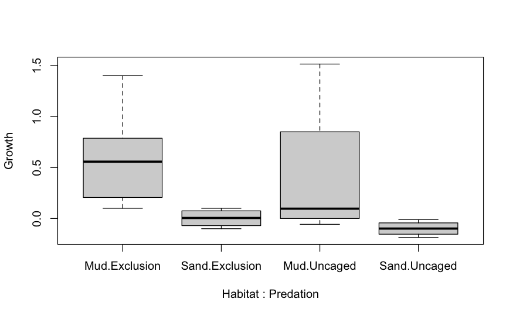

```r
boxplot(Growth~Habitat*Predation, df2)
```

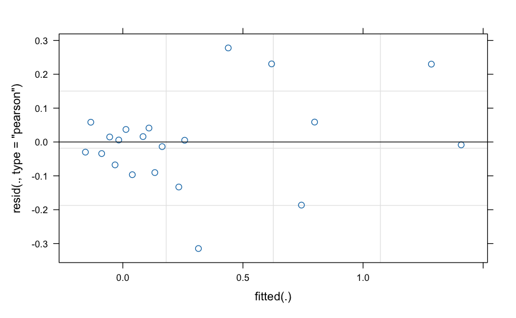

```r
seitz.lmer4 <- lmer(Growth~Habitat + Predation + Habitat*Predation + (1|Plot), REML=TRUE, df2)
plot(seitz.lmer4)
```

```r
#At this point, wedge-shaped pattern of residuals is a bit more conspicuous, so think about whether a transform might be useful
Lgrowth<-log(df2$Growth + 1)
summary(seitz.lmer4, ddf="Kenward-Roger")
```

```
Linear mixed model fit by REML. t-tests use Kenward-Roger's method ['lmerModLmerTest']
Formula: Growth ~ Habitat + Predation + Habitat * Predation + (1 | Plot)
   Data: df2

REML criterion at convergence: 24.4

Scaled residuals:
     Min       1Q   Median       3Q      Max
-1.56607 -0.33662  0.02525  0.20493  1.38215

Random effects:
 Groups   Name        Variance Std.Dev.
 Plot     (Intercept) 0.15159  0.3893
 Residual             0.04039  0.2010
Number of obs: 21, groups:  Plot, 11

Fixed effects:
                    Estimate Std. Error       df t value Pr(>|t|)
(Intercept)         0.233769   0.130340 8.901071   1.794   0.1068
Habitat1            0.281775   0.130340 8.901071   2.162   0.0592 .
Predation1          0.056299   0.045832 8.098174   1.228   0.2538
Habitat1:Predation1 0.005793   0.045832 8.098174   0.126   0.9025
---
Signif. codes:  0 ‘***’ 0.001 ‘**’ 0.01 ‘*’ 0.05 ‘.’ 0.1 ‘ ’ 1

Correlation of Fixed Effects:
            (Intr) Habtt1 Prdtn1
Habitat1    -0.265
Predation1  -0.018 -0.018
Hbtt1:Prdt1 -0.018 -0.018 -0.207
```

```r
anova (seitz.lmer4, ddf="Kenward-Roger")
```

```
Type III Analysis of Variance Table with Kenward-Roger's method
                    Sum Sq  Mean Sq NumDF  DenDF F value  Pr(>F)
Habitat           0.188745 0.188745     1 8.9011  4.6736 0.05922 .
Predation         0.060940 0.060940     1 8.0982  1.5089 0.25380
Habitat:Predation 0.000645 0.000645     1 8.0982  0.0160 0.90249
---
Signif. codes:  0 ‘***’ 0.001 ‘**’ 0.01 ‘*’ 0.05 ‘.’ 0.1 ‘ ’ 1
```

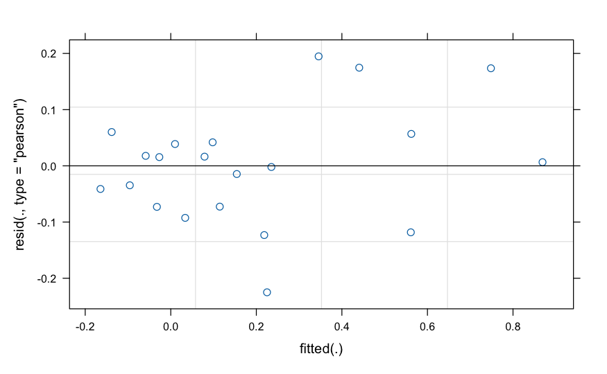

```r
seitz.lmer5 <- lmer(Lgrowth~Habitat + Predation + Habitat*Predation + (1|Plot), REML=TRUE, df2)
plot(seitz.lmer5)
```

```r
#Residuals don't look much better. Leave as is
```

```r
df3<-pivot_wider(df2,
                 names_from = Predation,
                 values_from = Growth
                 )
df3$Predation <-df3$Exclusion - df3$Uncaged
head(df3,10)
```

| Habitat | Plot | Exclusion | Uncaged | Predation |
| --- | --- | --- | --- | --- |
| Mud | 1 | 0.5571429 | 0.85000000 | -0.2928571 |
| Mud | 2 | 0.1000000 | 0.15000000 | -0.0500000 |
| Mud | 3 | 0.1500000 | -0.05714286 | 0.2071429 |
| Mud | 4 | 0.2625000 | 0.04285714 | 0.2196429 |
| Mud | 8 | 0.7166667 | 0.00000000 | 0.7166667 |
| Mud | 10 | 0.8571429 | NA | NA |
| Mud | 11 | 1.4000000 | 1.51428571 | -0.1142857 |
| Sand | 5 | -0.1000000 | -0.07500000 | -0.0250000 |
| Sand | 6 | -0.0400000 | -0.18571429 | 0.1457143 |
| Sand | 7 | 0.0500000 | -0.12222222 | 0.1722222 |

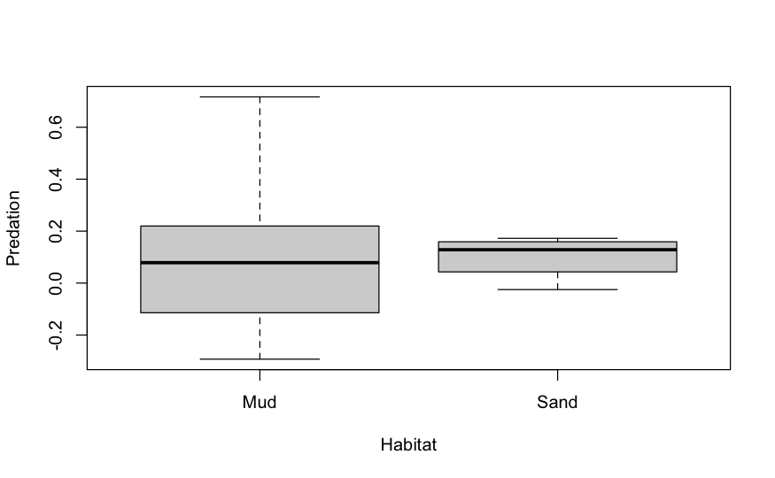

```r
boxplot(Predation~Habitat, df3)
```

```r
t.test(Predation~Habitat, data=df3, var.equal = FALSE)
```

```
    Welch Two Sample t-test

data:  Predation by Habitat
t = 0.088487, df = 5.8778, p-value = 0.9324
alternative hypothesis: true difference in means between group Mud and group Sand is not equal to 0
95 percent confidence interval:
 -0.3583016  0.3850476
sample estimates:
 mean in group Mud mean in group Sand
         0.1143849          0.1010119
```

## C.

Dalziel et al. (2015) were interested in disentangling the processes of acclimation and adaptation to changing environments, and examined levels of phenotypic plasticity in a small fish, the lake whitefish. This fish has developed two ecotypes - phenotypes that feed in different ways. Dwarf ecotypes are actively swimming and feeding, but slow-growing, while the ancestral normal phenotype is more sedentary. It’s thought that these ecotypes evolved separately under past climates, but then came together and can co-occur. There are anatomical and physiological differences between the ecotypes that are linked to swimming ability, and Dalziel and her colleagues were interested in how these ecotypes responed to a changed environment with faster-flowing water, particularly any role of phenotypic plasticity.

Phenotypic plasticity is best assessed by placing different phenotypes into the same set of varied environments and measuring their performance. They did this for whitefish by using roughly size-matched, laboratory-fertilized and reared fish from each ecotype, which were then placed in two environments, still water and fast-flowing water. Fish were kept in these environments for approximately 3 months, then sampled.

Flow environments were produced in 1 m high circular tanks, .6 m in diameter, with a .16 m diameter cylinder in the centre of the tank, creating a circular swimming “race track”. Within this track, water flowed at 7.6 cm/s for 6 h/day or 0.5 cm/s. Each tank contained 8 fish of each ecotype.

At the end of the experiment, fish were sacrficed, and the researchers took hematocrit samples, measured heart morphology and took samples of red and white muscle. Red mussel samples were used for enzyme assays and histology, and white muscle to obtain mitochondria, whose performance was assessed.

They provided data and R code through dryad. We’ll focus on their data focusing on mitochondrial function in white muscle. These data are in their file *Fig5_MitoRespiration.csv.* If you want to explore some of their other analyses, you can use their R script, which allows easy selection of data files.

```r
plasticity<-read.csv("data/Fig5_MitoRespiration.csv",header=TRUE,stringsAsFactors = FALSE, na.strings = c("NA",""))
head(plasticity, 10)
```

|  | indv | ecotype | treatment | group | tank | mass | length | mitoprotein.ml | mitoprotein.gWM | state2.ml | state2.mg | state3.ml | state3.mg | state4.ml | state4.mg | RCR | ACR | flux1.4.ml | flux1.4.mg | flux2.4.ml | flux2.4.mg | flux.cox.ml | flux.cox.mg | notes1 |
| --- | --- | --- | --- | --- | --- | --- | --- | --- | --- | --- | --- | --- | --- | --- | --- | --- | --- | --- | --- | --- | --- | --- | --- | --- |
| 1 | WP1 | dwarf | swim | DS | 1 | 3.2197 | 7.580 | 6.25 | 0.622 | 74.0 | 11.8 | 404.2 | 64.7 | 137.8 | 22.0 | 2.9 | 5.5 | 350.5 | 56.1 | 89.8 | 14.4 | 955.9 | 152.9 | mitoprotein.ml=mitochondrial protein per mL mito resuspension (from BSA assay) |
| 2 | WP2 | dwarf | control | DC | 2 | 4.1880 | 7.959 | 5.26 | 0.526 | 42.3 | 8.1 | 344.9 | 65.6 | 128.7 | 24.5 | 2.7 | 8.1 | 404.8 | 77.0 | 121.2 | 23.0 | 388.4 | 73.8 | mitoprotein.gWM1= mitochondrial protein per gram tissue based upon calculations from uL buffer added |
| 3 | WP3 | normal | swim | NS | 3 | 3.2915 | 6.501 | 4.49 | 0.458 | 24.3 | 5.4 | 261.3 | 58.2 | 122.5 | 27.3 | 2.1 | 10.8 | 286.4 | 63.8 | 98.0 | 21.8 | 264.0 | 58.8 | NA |
| 4 | WP4 | normal | control | NC | 4 | 4.6945 | 7.840 | 3.40 | 0.260 | 33.5 | 9.9 | 331.9 | 97.6 | 90.0 | 26.5 | 3.7 | 9.9 | 405.9 | 119.4 | 96.0 | 28.2 | 750.7 | 220.8 | NA |
| 5 | WP5 | normal | control | NC | 5 | 4.2127 | 7.582 | 3.49 | 0.347 | 28.3 | 8.1 | 266.1 | 76.2 | 63.7 | 18.3 | 4.2 | 9.4 | 310.8 | 89.1 | 97.3 | 27.9 | 608.3 | 174.3 | NA |
| 6 | WP6 | normal | swim | NS | 6 | 3.7213 | 7.133 | 4.16 | 0.435 | NA | NA | NA | NA | NA | NA | NA | NA | NA | NA | NA | NA | NA | NA | NA |
| 7 | WP7 | normal | control | NC | 7 | 3.9910 | 7.766 | 5.28 | 0.541 | 27.7 | 5.2 | 249.2 | 47.2 | 77.4 | 14.7 | 3.2 | 9.0 | 388.8 | 73.6 | 47.9 | 9.1 | 671.8 | 127.2 | NA |
| 8 | WP8 | dwarf | swim | DS | 8 | 5.8855 | 9.091 | 4.84 | 0.484 | 53.4 | 11.0 | 548.8 | 113.4 | 69.0 | 14.2 | 8.0 | 10.3 | 675.8 | 139.6 | 171.1 | 35.4 | 1143.5 | 236.3 | NA |
| 9 | WP9 | normal | swim | NS | 8 | 4.5422 | 7.742 | 2.92 | 0.299 | 34.9 | 12.0 | 248.3 | 85.0 | 61.8 | 21.2 | 4.0 | 7.1 | 281.3 | 96.3 | 59.7 | 20.5 | 687.1 | 235.3 | NA |
| 10 | WP10 | normal | control | NC | 7 | 4.8839 | NA | 4.22 | 0.427 | 39.3 | 9.3 | 306.7 | 72.7 | 59.1 | 14.0 | 5.2 | 7.8 | 374.8 | 88.8 | 94.9 | 22.5 | 748.6 | 177.4 | NA |

**Look at data measuring fluxes of four oxidative complexes, I-IV. These are the variables flux1.4.mg, flux2.4mg, and flux.cox.mg**

flux1.4.mg is total flux across the four complexes, flux2.4.mg is flux across complexes II-IV, and flux.cox.mg is flux across complex IV

```r
#Make sure categorical predictors are treated the right way
plasticity$treatment <-as.factor(plasticity$treatment)
plasticity$ecotype <-as.factor(plasticity$ecotype)
plasticity$tank <-as.factor(plasticity$tank)
```

### What do you conclude about the ecotypes and their plasticity for these mitochondrial fluxes?

> Students should check that the fluxes are independent

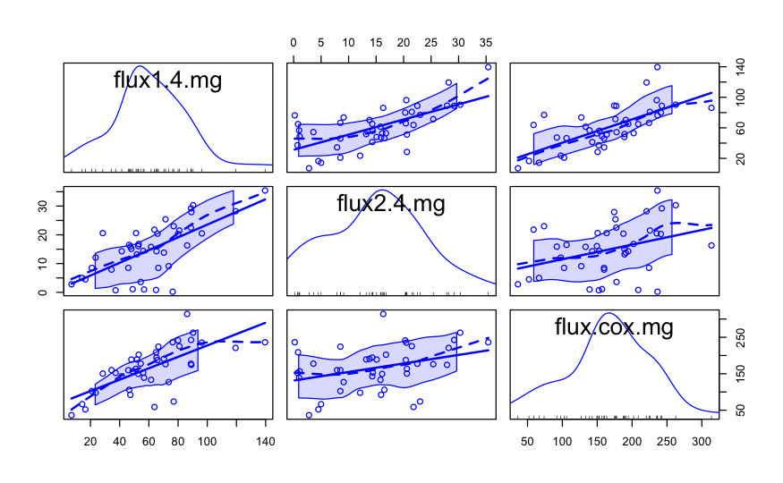

```r
scatterplotMatrix(data = plasticity, ~ flux1.4.mg + flux2.4.mg + flux.cox.mg)
```

> Be a bit cautious about interpreting results for all 3

```r
plasticity.lmer <- lmer(flux1.4.mg ~ ecotype*treatment + (1|tank), REML=TRUE, plasticity)
```

```
boundary (singular) fit: see help('isSingular')
```

```r
anova(plasticity.lmer)
```

```
Type III Analysis of Variance Table with Satterthwaite's method
                  Sum Sq Mean Sq NumDF DenDF F value  Pr(>F)
ecotype             54.5    54.5     1    40  0.0794 0.77962
treatment           50.5    50.5     1    40  0.0735 0.78772
ecotype:treatment 4756.6  4756.6     1    40  6.9221 0.01203 *
---
Signif. codes:  0 ‘***’ 0.001 ‘**’ 0.01 ‘*’ 0.05 ‘.’ 0.1 ‘ ’ 1
```

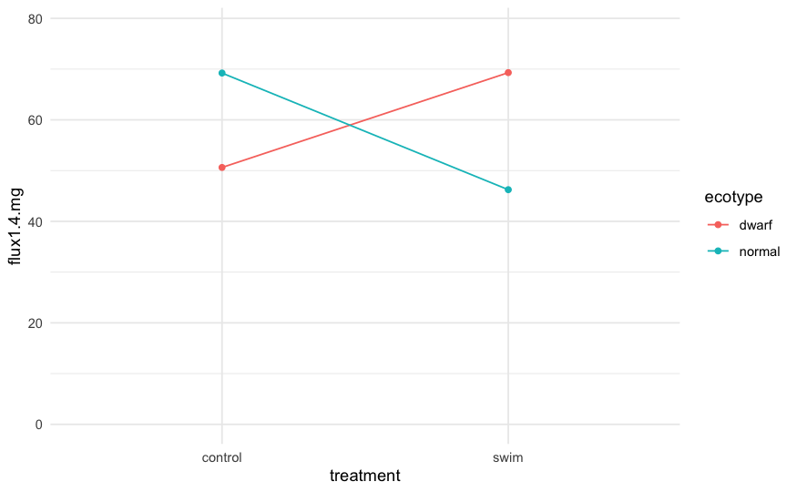

```r
ggplot(data=subset(plasticity, !is.na(flux1.4.mg)), aes(x = treatment, y = flux1.4.mg, group=ecotype, colour = ecotype))+
  geom_line(stat = "summary")+
  geom_point(stat = "summary")+
  theme_minimal()+
  ylim(0,NA)
```

```r
plasticity.lmer <- lmer(flux2.4.mg ~ ecotype*treatment + (1|tank), REML=TRUE, plasticity)
```

```
boundary (singular) fit: see help('isSingular')
```

```r
anova(plasticity.lmer)
```

```
Type III Analysis of Variance Table with Satterthwaite's method
                  Sum Sq Mean Sq NumDF DenDF F value  Pr(>F)
ecotype           317.87  317.87     1    39  3.8894 0.05571 .
treatment          19.42   19.42     1    39  0.2376 0.62869
ecotype:treatment  66.40   66.40     1    39  0.8124 0.37294
---
Signif. codes:  0 ‘***’ 0.001 ‘**’ 0.01 ‘*’ 0.05 ‘.’ 0.1 ‘ ’ 1
```

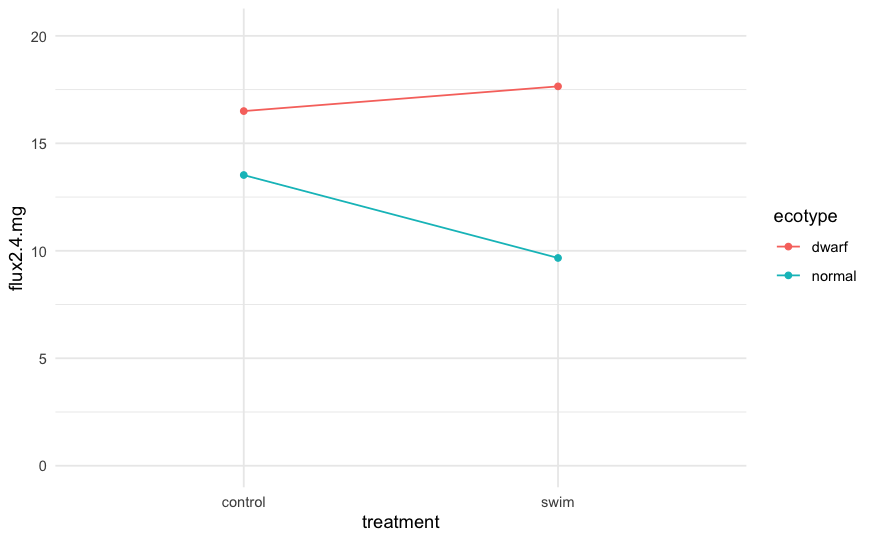

```r
ggplot(data=subset(plasticity, !is.na(flux2.4.mg)), aes(x = treatment, y = flux2.4.mg, group=ecotype, colour = ecotype))+
  geom_line(stat = "summary")+
  geom_point(stat = "summary")+
  theme_minimal()+
  ylim(0,NA)
```

```r
plasticity.lmer <- lmer(flux.cox.mg ~ ecotype*treatment + (1|tank), REML=TRUE, plasticity)
anova(plasticity.lmer)
```

```
Type III Analysis of Variance Table with Satterthwaite's method
                   Sum Sq Mean Sq NumDF  DenDF F value   Pr(>F)
ecotype            1903.1  1903.1     1 40.964  0.4963 0.485105
treatment           720.3   720.3     1  5.698  0.1879 0.680628
ecotype:treatment 29534.2 29534.2     1 40.964  7.7023 0.008273 **
---
Signif. codes:  0 ‘***’ 0.001 ‘**’ 0.01 ‘*’ 0.05 ‘.’ 0.1 ‘ ’ 1
```

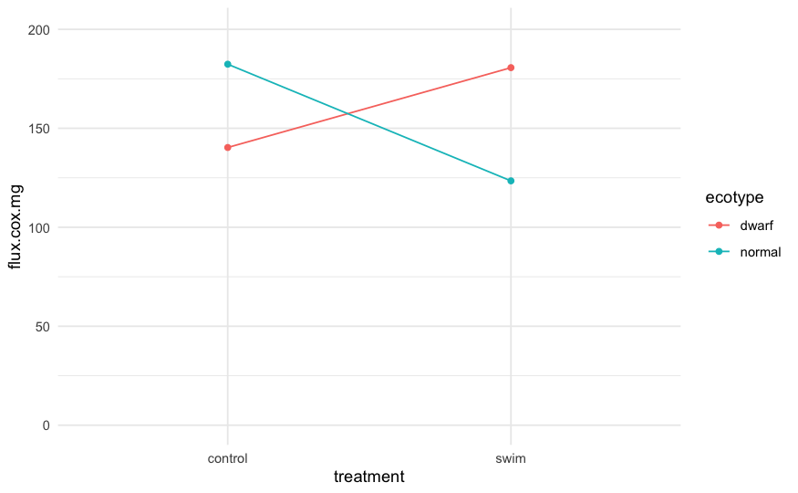

```r
ggplot(data=subset(plasticity, !is.na(flux.cox.mg)), aes(x = treatment, y = flux.cox.mg, group=ecotype, colour = ecotype))+
  geom_line(stat = "summary")+
  geom_point(stat = "summary")+
  theme_minimal()+
  ylim(0,NA)
```

> The analysis suggests a detectable interaction between ecotype and treatment for Complex I-IV and for IV, but not for II-IV.

> Simplest way to investigate is to look at interaction plots. For CI-IV, it looks like both ecotypes show plasticity, but in the opposite direction. Fluxes rise for dwarf ecotype under swimming, but fall for the normal ecotype. That pattern is also seen for the Complex IV alone. For II-IV, the patterns aren’t distinguishable from noise under the anova criteria we’ve used, but patterns of means are similar.

## D.

Morrissette-Boileau et al. (2018) examined factors affecting a shrub (dwarf birch) that is potentially expanding its range northwards with warming. They were interested in modifying factors - enhanced nutrients, warming, and browsing by caribou.

Caribou were not manipulated directly, but were excluded by fencing them out, and their foraging simulated by manual removal of 0, 25, or 75% of available shoots once each spring.

Nutrients were manipulated in 4 x 24 m plots, half of which received a nutrient supplement at bud-burst each year.

Each 4 x 24 area was divided into 4 x 4 m sub-plots. Each of these sub-plots had a 1 m x 1m area that was the subject of a combination of warming and caribou treatments.

Global warming was simulated using open-top hexagonal chambers that trap solar energy. They were used to establish two levels, ambient and warmed. Warming was applied to the target 1 x 1 m area thoughout the growing season.

The experiment ran for 5 years, after which time the authors recorded the total leafy biomass from each birch stem in the 1 x 1 target area. This time was the start of the 2014 growing season.

Their data are available from [dryad](https://datadryad.org/stash/dataset/doi:10.5061/dryad.50t9d). The relevant files are inside_productivity.csv and a very clear README_for_inside_productivity.txt file. We won’t explain the variables, and just point you to the readme. Figure 1 of the paper also has a nice diagram of the experiment.

Start by taking a quick look at the data file. The variables you may be working with for now are block, fertilization, temp, browsing, and biomass. **Note that this file has a semicolon rather than comma as the delimiter, so make sure you take account of that when importing the data**

```r
df <- read_delim("data/inside_productivity.csv",
                 delim = ";", escape_double = FALSE, trim_ws = TRUE)
set_sum_contrasts()
```

```
setting contr.sum globally: options(contrasts=c('contr.sum', 'contr.poly'))
```

```r
head(df, 10)
```

| Biomass | Block | Fertilization | Temp | Browsing | Parcelle_id | Biomass_beg2009 | Biomass_end2009 |
| --- | --- | --- | --- | --- | --- | --- | --- |
| 535.30 | A | N | H | 0 | ANH0 | 41 | 53 |
| 470.52 | A | N | H | 1 | ANH1 | 34 | 71 |
| 243.51 | A | N | H | 3 | ANH3 | 20 | 45 |
| 1171.89 | A | N | L | 0 | ANL0 | 25 | 61 |
| 775.68 | A | N | L | 1 | ANL1 | 27 | 56 |
| 928.05 | A | N | L | 3 | ANL3 | 32 | 64 |
| 1273.95 | A | S | H | 0 | ASH0 | 30 | 78 |
| 851.81 | A | S | H | 1 | ASH1 | 28 | 56 |
| 1219.47 | A | S | H | 3 | ASH3 | 22 | 34 |
| 1139.32 | A | S | L | 0 | ASL0 | 17 | 65 |

```r
df$Browsing <- as.factor(df$Browsing)
df$Block <- as.factor(df$Block)
df$Temp <- as.factor(df$Temp)
df$Fertilization <-as.factor(df$Fertilization)
```

### Outline how you’d assess the combined effects of fertilization, temperature, and browsing on biomass

Make sure you think carefully about scales of experimental units, which factors are between- and which are within-plots, and which are fixed vs random.

> 4 factors - fert, warming, browsing, block nutrients, block(nutrients), then fert x warming within each block. blocks is a random effect; all others are fixed

**Make sure you include initial checking of assumptions**

```r
df$lbiomass <- log(df$Biomass)
```

#### This means telling us what these effects are, and producing a graph (or several)!

> We could fit the model a couple of ways, as shown on Box 11.5; suggest using lmer

```r
df3.aov <- aov(lbiomass ~ Fertilization*Temp*Browsing + Error(Block/(Temp*Browsing)), df)
summary(df3.aov)
```

```
Error: Block
          Df Sum Sq Mean Sq F value Pr(>F)
Residuals  4  1.302  0.3255

Error: Block:Temp
          Df Sum Sq Mean Sq F value Pr(>F)
Temp       1 0.6969  0.6969   5.279 0.0832 .
Residuals  4 0.5281  0.1320
---
Signif. codes:  0 ‘***’ 0.001 ‘**’ 0.01 ‘*’ 0.05 ‘.’ 0.1 ‘ ’ 1

Error: Block:Browsing
          Df Sum Sq Mean Sq F value Pr(>F)
Browsing   2 0.4176  0.2088   0.685  0.531
Residuals  8 2.4386  0.3048

Error: Block:Temp:Browsing
              Df Sum Sq Mean Sq F value Pr(>F)
Temp:Browsing  2 0.2804  0.1402   0.773  0.493
Residuals      8 1.4502  0.1813

Error: Within
                            Df Sum Sq Mean Sq F value Pr(>F)
Fertilization                1  0.086 0.08588   0.494  0.489
Fertilization:Temp           1  0.187 0.18694   1.076  0.310
Fertilization:Browsing       2  0.621 0.31063   1.787  0.189
Fertilization:Temp:Browsing  2  0.062 0.03086   0.178  0.838
Residuals                   24  4.171 0.17379
```

> Also run as linear mixed effect model using lmer or lme4

**In the paper, the authors used initial biomass (Biomass_end2009) as a covariate, to account for initial variation in the number of stems occurring in sub-plots. Does inclusion of initial biomass improve the model fit?**

```r
df.lmer <- lmer(Biomass ~ Fertilization*Temp*Browsing + (1|Block) + (1|Block:Temp) + (1|Block:Browsing), REML=TRUE, df)
```

```
boundary (singular) fit: see help('isSingular')
```

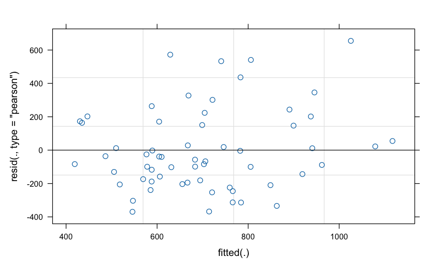

```r
plot(df.lmer)
```

```r
summary(df.lmer, ddf="Kenward-Roger")
```

```
Linear mixed model fit by REML. t-tests use Kenward-Roger's method ['lmerModLmerTest']
Formula: Biomass ~ Fertilization * Temp * Browsing + (1 | Block) + (1 |      Block:Temp) + (1 | Block:Browsing)
   Data: df

REML criterion at convergence: 731.9

Scaled residuals:
    Min      1Q  Median      3Q     Max
-1.2801 -0.6336 -0.1689  0.5735  2.2689

Random effects:
 Groups         Name        Variance Std.Dev.
 Block:Browsing (Intercept) 14340    119.75
 Block:Temp     (Intercept)     0      0.00
 Block          (Intercept)  2722     52.17
 Residual                   83337    288.68
Number of obs: 60, groups:  Block:Browsing, 15; Block:Temp, 10; Block, 5

Fixed effects:
                               Estimate Std. Error      df t value Pr(>|t|)
(Intercept)                     700.887     53.752   4.000  13.039   0.0002 ***
Fertilization1                   31.401     37.269  32.000   0.843   0.4057
Temp1                           -73.370     37.269   4.000  -1.969   0.1204
Browsing1                        64.182     68.483   8.000   0.937   0.3761
Browsing2                        27.789     68.483   8.000   0.406   0.6955
Fertilization1:Temp1            -34.950     37.269  32.000  -0.938   0.3554
Fertilization1:Browsing1         18.167     52.706  32.000   0.345   0.7326
Fertilization1:Browsing2         72.693     52.706  32.000   1.379   0.1774
Temp1:Browsing1                 -65.232     52.706  32.000  -1.238   0.2248
Temp1:Browsing2                  11.951     52.706  32.000   0.227   0.8221
Fertilization1:Temp1:Browsing1   -5.197     52.706  32.000  -0.099   0.9221
Fertilization1:Temp1:Browsing2   28.947     52.706  32.000   0.549   0.5867
---
Signif. codes:  0 ‘***’ 0.001 ‘**’ 0.01 ‘*’ 0.05 ‘.’ 0.1 ‘ ’ 1

Correlation of Fixed Effects:
            (Intr) Frtlz1 Temp1  Brwsn1 Brwsn2 Fr1:T1 Fr1:B1 Fr1:B2 Tm1:B1 Tm1:B2 F1:T1:B1
Fertiliztn1  0.000
Temp1        0.000  0.000
Browsing1    0.000  0.000  0.000
Browsing2    0.000  0.000  0.000 -0.500
Frtlztn1:T1  0.000  0.000  0.000  0.000  0.000
Frtlztn1:B1  0.000  0.000  0.000  0.000  0.000  0.000
Frtlztn1:B2  0.000  0.000  0.000  0.000  0.000  0.000 -0.500
Tmp1:Brwsn1  0.000  0.000  0.000  0.000  0.000  0.000  0.000  0.000
Tmp1:Brwsn2  0.000  0.000  0.000  0.000  0.000  0.000  0.000  0.000 -0.500
Frtl1:T1:B1  0.000  0.000  0.000  0.000  0.000  0.000  0.000  0.000  0.000  0.000
Frtl1:T1:B2  0.000  0.000  0.000  0.000  0.000  0.000  0.000  0.000  0.000  0.000 -0.500
optimizer (nloptwrap) convergence code: 0 (OK)
boundary (singular) fit: see help('isSingular')
```

```r
anova(df.lmer, ddf="Kenward-Roger")
```

```
Type III Analysis of Variance Table with Kenward-Roger's method
                            Sum Sq Mean Sq NumDF DenDF F value Pr(>F)
Fertilization                59160   59160     1    32  0.7099 0.4057
Temp                        322989  322989     1     4  3.8757 0.1204
Browsing                    158151   79076     2     8  0.9489 0.4268
Fertilization:Temp           73290   73290     1    32  0.8794 0.3554
Fertilization:Browsing      277398  138699     2    32  1.6643 0.2053
Temp:Browsing               144740   72370     2    32  0.8684 0.4293
Fertilization:Temp:Browsing  28580   14290     2    32  0.1715 0.8432
```

```r
df1.lmer <- lmer(Biomass ~ Fertilization*Temp*Browsing + Biomass_end2009 + (1|Block) + (1|Block:Temp) + (1|Block:Browsing), REML=TRUE, df)
```

```
boundary (singular) fit: see help('isSingular')
```

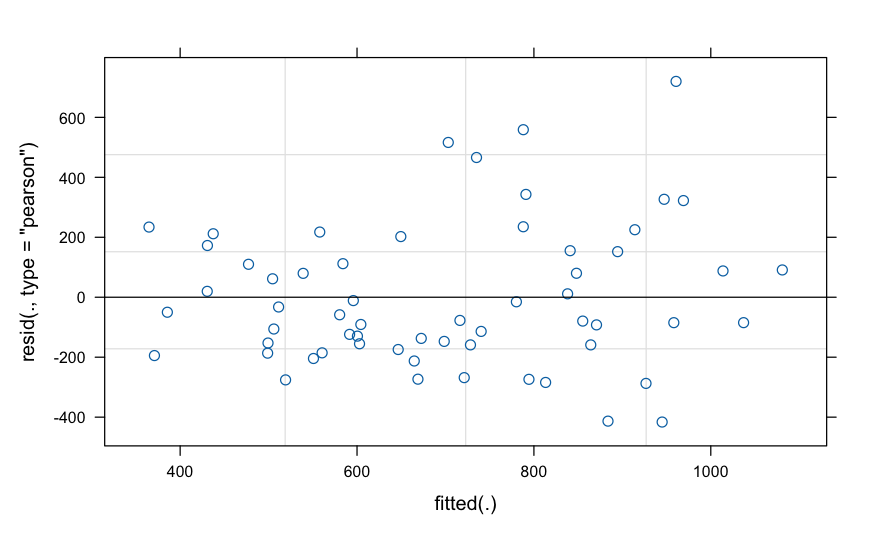

```r
plot(df1.lmer)
```

```r
anova(df1.lmer, ddf="Kenward-Roger")
```

```
Type III Analysis of Variance Table with Kenward-Roger's method
                            Sum Sq Mean Sq NumDF  DenDF F value  Pr(>F)
Fertilization                19379   19379     1 31.414  0.2494 0.62097
Temp                        111661  111661     1  4.598  1.4371 0.28872
Browsing                     34189   17094     2  8.365  0.2200 0.80705
Biomass_end2009             450030  450030     1 45.169  5.7919 0.02025 *
Fertilization:Temp          182511  182511     1 31.978  2.3489 0.13520
Fertilization:Browsing      126287   63143     2 31.481  0.8127 0.45277
Temp:Browsing               114534   57267     2 31.106  0.7370 0.48670
Fertilization:Temp:Browsing  66413   33207     2 31.216  0.4274 0.65598
---
Signif. codes:  0 ‘***’ 0.001 ‘**’ 0.01 ‘*’ 0.05 ‘.’ 0.1 ‘ ’ 1
```

```r
anova(df.lmer, df1.lmer)
```

```
refitting model(s) with ML (instead of REML)
```

```
Data: df
Models:
df.lmer: Biomass ~ Fertilization * Temp * Browsing + (1 | Block) + (1 | Block:Temp) + (1 | Block:Browsing)
df1.lmer: Biomass ~ Fertilization * Temp * Browsing + Biomass_end2009 + (1 | Block) + (1 | Block:Temp) + (1 | Block:Browsing)
         npar    AIC    BIC  logLik deviance  Chisq Df Pr(>Chisq)
df.lmer    16 877.62 911.13 -422.81   845.62
df1.lmer   17 871.40 907.00 -418.70   837.40 8.2244  1   0.004133 **
---
Signif. codes:  0 ‘***’ 0.001 ‘**’ 0.01 ‘*’ 0.05 ‘.’ 0.1 ‘ ’ 1
```

> Including biomass improves fit of the model markedly. Keep it in.

Examine the residuals, and see if you think the response variable needs transformation, and if you do a transform, does the model fit any better?

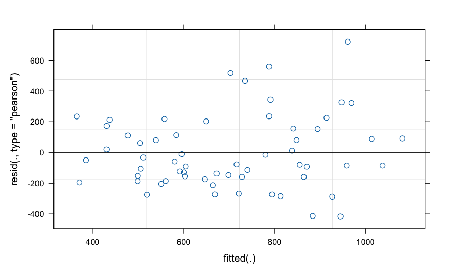

```r
plot(df1.lmer)
```

```r
df2.lmer <- lmer(log(Biomass) ~ Fertilization*Temp*Browsing + Biomass_end2009 + (1|Block) + (1|Block:Temp) + (1|Block:Browsing), REML=TRUE, df)
```

```
boundary (singular) fit: see help('isSingular')
```

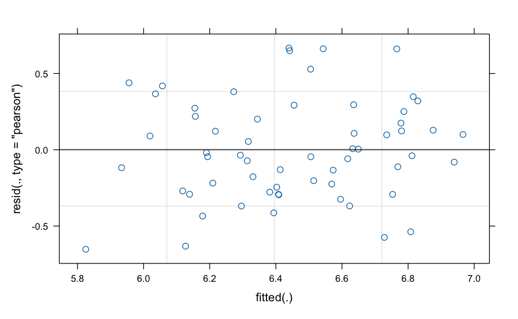

```r
plot(df2.lmer)
```

```r
anova(df1.lmer, df2.lmer)
```

```
refitting model(s) with ML (instead of REML)
```

```
Data: df
Models:
df1.lmer: Biomass ~ Fertilization * Temp * Browsing + Biomass_end2009 + (1 | Block) + (1 | Block:Temp) + (1 | Block:Browsing)
df2.lmer: log(Biomass) ~ Fertilization * Temp * Browsing + Biomass_end2009 + (1 | Block) + (1 | Block:Temp) + (1 | Block:Browsing)
         npar    AIC    BIC  logLik deviance  Chisq Df Pr(>Chisq)
df1.lmer   17 871.40 907.00 -418.70   837.40
df2.lmer   17  81.59 117.19  -23.79    47.59 789.81  0
```

> Residual plots look OK in both cases; spread a bit more even in the case of the log-transformed values. Go with log-transform.

```r
summary(df2.lmer, ddf="Kenward-Roger")
```

```
Linear mixed model fit by REML. t-tests use Kenward-Roger's method ['lmerModLmerTest']
Formula: log(Biomass) ~ Fertilization * Temp * Browsing + Biomass_end2009 +      (1 | Block) + (1 | Block:Temp) + (1 | Block:Browsing)
   Data: df

REML criterion at convergence: 102.7

Scaled residuals:
     Min       1Q   Median       3Q      Max
-1.69166 -0.65201 -0.09715  0.58779  1.72815

Random effects:
 Groups         Name        Variance Std.Dev.
 Block:Browsing (Intercept) 0.018490 0.13598
 Block:Temp     (Intercept) 0.000000 0.00000
 Block          (Intercept) 0.000823 0.02869
 Residual                   0.148825 0.38578
Number of obs: 60, groups:  Block:Browsing, 15; Block:Temp, 10; Block, 5

Fixed effects:
                                Estimate Std. Error        df t value Pr(>|t|)
(Intercept)                     5.774061   0.236503 40.259856  24.414   <2e-16 ***
Fertilization1                  0.015193   0.050382 31.414004   0.302   0.7650
Temp1                          -0.059776   0.052352  4.598212  -1.142   0.3095
Browsing1                       0.032343   0.088956  8.462632   0.364   0.7251
Browsing2                      -0.010887   0.086406  7.799225  -0.126   0.9029
Biomass_end2009                 0.013584   0.004566 44.990286   2.975   0.0047 **
Fertilization1:Temp1           -0.093401   0.051381 31.977265  -1.818   0.0785 .
Fertilization1:Browsing1        0.023906   0.070513 31.111014   0.339   0.7369
Fertilization1:Browsing2        0.066383   0.071571 31.543464   0.928   0.3607
Temp1:Browsing1                -0.084851   0.070544 31.124084  -1.203   0.2381
Temp1:Browsing2                 0.044304   0.070434 31.078418   0.629   0.5339
Fertilization1:Temp1:Browsing1  0.015981   0.070536 31.120614   0.227   0.8222
Fertilization1:Temp1:Browsing2  0.046471   0.071093 31.349849   0.654   0.5181
---
Signif. codes:  0 ‘***’ 0.001 ‘**’ 0.01 ‘*’ 0.05 ‘.’ 0.1 ‘ ’ 1
```

```
Correlation matrix not shown by default, as p = 13 > 12.
Use print(x, correlation=TRUE)  or
    vcov(x)        if you need it
```

```
optimizer (nloptwrap) convergence code: 0 (OK)
boundary (singular) fit: see help('isSingular')
```

```r
anova(df2.lmer, ddf="Kenward-Roger")
```

```
Type III Analysis of Variance Table with Kenward-Roger's method
                             Sum Sq Mean Sq NumDF  DenDF F value  Pr(>F)
Fertilization               0.01353 0.01353     1 31.414  0.0909 0.76497
Temp                        0.19403 0.19403     1  4.598  1.3037 0.30948
Browsing                    0.02003 0.01001     2  8.357  0.0673 0.93545
Biomass_end2009             1.31712 1.31712     1 44.990  8.8501 0.00470 **
Fertilization:Temp          0.49179 0.49179     1 31.977  3.3045 0.07847 .
Fertilization:Browsing      0.24829 0.12415     2 31.481  0.8342 0.44361
Temp:Browsing               0.21547 0.10773     2 31.106  0.7239 0.49285
Fertilization:Temp:Browsing 0.12480 0.06240     2 31.216  0.4193 0.66115
---
Signif. codes:  0 ‘***’ 0.001 ‘**’ 0.01 ‘*’ 0.05 ‘.’ 0.1 ‘ ’ 1
```

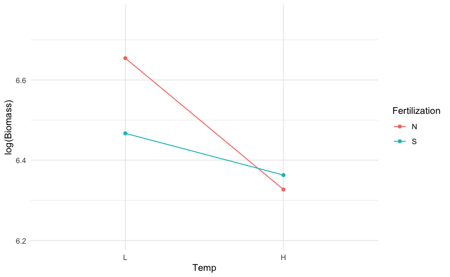

```r
ggplot(data = df, aes(x=Temp, y=log(Biomass), group=Fertilization, colour=Fertilization))+
  geom_line(stat = "summary") +
  geom_point(stat = "summary")+
  scale_x_discrete(limits=rev)+
  theme_minimal()
```

> In this case, we’re not picking up much beyond an effect of initial biomass. In the original paper, the authors looked at a “marginal” interaction between nutrients and warming. That can be visualized with a simple interaction plot if desired.

#### A simpler model

In the discussion of the paper, there is discussion over the success of the method used to produce Warming. The technique has been used before, but data loggers in place during the experiment suggested no consistent warming was produced.

**Would a simpler model omitting Warming lead you to any different conclusions?**

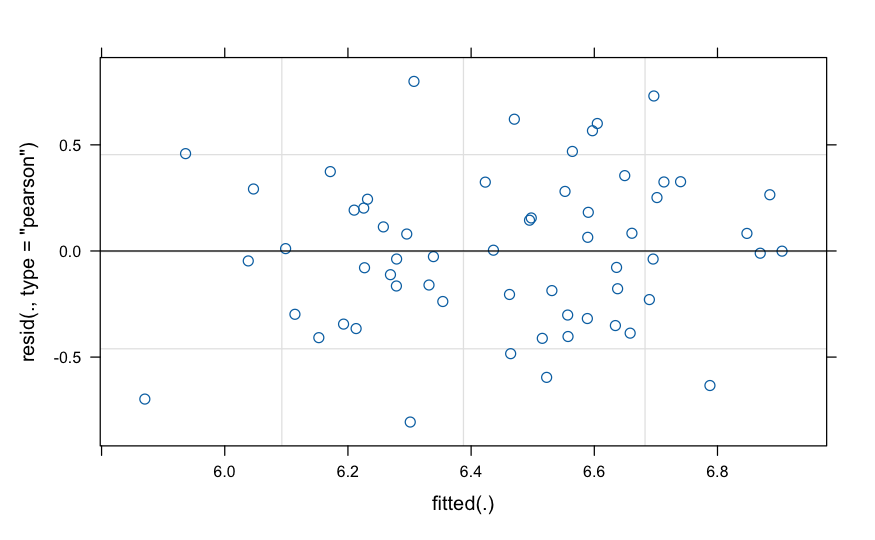

```r
df3.lmer <- lmer(log(Biomass) ~ Fertilization*Browsing + Biomass_end2009 + (1|Block) + (1|Block:Browsing), REML=TRUE, df)
plot(df3.lmer)
```

```r
anova(df3.lmer, df2.lmer)
```

```
refitting model(s) with ML (instead of REML)
```

```
Data: df
Models:
df3.lmer: log(Biomass) ~ Fertilization * Browsing + Biomass_end2009 + (1 | Block) + (1 | Block:Browsing)
df2.lmer: log(Biomass) ~ Fertilization * Temp * Browsing + Biomass_end2009 + (1 | Block) + (1 | Block:Temp) + (1 | Block:Browsing)
         npar    AIC     BIC  logLik deviance  Chisq Df Pr(>Chisq)
df3.lmer   10 76.014  96.958 -28.007   56.014
df2.lmer   17 81.590 117.194 -23.795   47.590 8.4244  7     0.2967
```

```r
summary(df3.lmer, ddf="Kenward-Roger")
```

```
Linear mixed model fit by REML. t-tests use Kenward-Roger's method ['lmerModLmerTest']
Formula: log(Biomass) ~ Fertilization * Browsing + Biomass_end2009 + (1 |      Block) + (1 | Block:Browsing)
   Data: df

REML criterion at convergence: 87.3

Scaled residuals:
    Min      1Q  Median      3Q     Max
-2.0590 -0.6467 -0.0145  0.6513  2.0411

Random effects:
 Groups         Name        Variance  Std.Dev.
 Block:Browsing (Intercept) 0.0175723 0.13256
 Block          (Intercept) 0.0007708 0.02776
 Residual                   0.1532308 0.39145
Number of obs: 60, groups:  Block:Browsing, 15; Block, 5

Fixed effects:
                          Estimate Std. Error        df t value Pr(>|t|)
(Intercept)               5.791944   0.218121 45.037479  26.554  < 2e-16 ***
Fertilization1            0.015790   0.051014 41.339194   0.310  0.75849
Browsing1                 0.034073   0.088654  8.420538   0.384  0.71025
Browsing2                -0.010392   0.086511  7.822116  -0.120  0.90742
Biomass_end2009           0.013226   0.004184 52.378872   3.161  0.00261 **
Fertilization1:Browsing1  0.024168   0.071534 41.074300   0.338  0.73719
Fertilization1:Browsing2  0.067379   0.072411 41.452293   0.931  0.35749
---
Signif. codes:  0 ‘***’ 0.001 ‘**’ 0.01 ‘*’ 0.05 ‘.’ 0.1 ‘ ’ 1

Correlation of Fixed Effects:
            (Intr) Frtlz1 Brwsn1 Brwsn2 B_2009 Fr1:B1
Fertiliztn1  0.121
Browsing1    0.202  0.027
Browsing2    0.059  0.008 -0.475
Bmss_nd2009 -0.952 -0.127 -0.212 -0.062
Frtlztn1:B1  0.038  0.005  0.008  0.002 -0.040
Frtlztn1:B2  0.142  0.019  0.032  0.009 -0.149 -0.488
```

```r
anova(df3.lmer, ddf="Kenward-Roger")
```

```
Type III Analysis of Variance Table with Kenward-Roger's method
                        Sum Sq Mean Sq NumDF  DenDF F value  Pr(>F)
Fertilization          0.01468 0.01468     1 41.339  0.0958 0.75849
Browsing               0.02336 0.01168     2  8.330  0.0762 0.92726
Biomass_end2009        1.53151 1.53151     1 52.379  9.9948 0.00261 **
Fertilization:Browsing 0.25797 0.12899     2 41.399  0.8418 0.43819
---
Signif. codes:  0 ‘***’ 0.001 ‘**’ 0.01 ‘*’ 0.05 ‘.’ 0.1 ‘ ’ 1
```

> Omitting the Warming factor doesn’t worsen the fit of the model unreasonably (as measured by the LR test for the fit of the two models.

> Interestingly, we might have expected the analysis to be more sensitive because some degrees of freedom have been moved around, the formal tests provide much little indication of any nutrient effect.

### Extension activities

#### Examine other responses

The paper includes other response variables. One you could get practice with is *gr_experiment.csv*. This file has data for 3-6 shoots from each sub-plot, which underwent dendrochronological analysis. The shoots were sectioned and growth increments for each year between 1966-2013 recorded. These increments for each shoot are repeated measures, with the individual shoots as the “subjects”.

Think about how you might analyse this data set. If you want, you could try analyzing the full data set. An alternative could be to look at some slightly simpler ways:

- Take just the years of the experiment (2010-2013) and look for trends across this period
- Examine only the final ring (2013)
- Take the average of the ring increments during the experiment.

If you analyze a single ring or an average, you’ll then have multiple measurements for each sub-plots. Are these values independent experimental units, or should they be averaged?

#### More complexity

We’ve just considered the 4 x 24 m plots in which nutrients were in which nutrients were manipulated, but in the actual experiment, these plots were themselves grouped within 5 caribou fences, each with 12 plots.

You could challenge yourself by thinking about how you’d incorporate this aspect into your model & analysis, including the complications that might arise from adding a second random factor.

## References

Dalziel, Anne C., Nicolas Martin, Martin Laporte, Helga Guderley, and Louis Bernatchez. 2015. “Adaptation and Acclimation of Aerobic Exercise Physiology in Lake Whitefish Ecotypes (Coregonus Clupeaformis).” *Evolution* 69 (8): 2167–86. https://doi.org/f7ptnz.

Li, Hong-Li, Yong-Yang Wang, Qian Zhang, Pu Wang, Ming-Xiang Zhang, and Fei-Hai Yu. 2015. “Vegetative Propagule Pressure and Water Depth Affect Biomass and Evenness of Submerged Macrophyte Communities.” *Plos One* 10 (11). https://doi.org/f8bw5m.

Morrissette-Boileau, Clara, Stéphane Boudreau, Jean-Pierre Tremblay, Steeve D. Côté, and Frank Gilliam. 2018. “Simulated Caribou Browsing Limits the Effect of Nutrient Addition on the Growth of Betula Glandulosa, an Expanding Shrub Species in Eastern Canada.” *Journal of Ecology* 106 (3): 1256–65. https://doi.org/gc8qqn.

Seitz, Rochelle D., Romuald N. Lipcius, and Anson H. Hines. 2016. “Consumer Versus Resource Control and the Importance of Habitat Heterogeneity for Estuarine Bivalves.” *Oikos* 126 (1): 121–35. https://doi.org/f9mh38.